# Mineração de Dados

02 de abril de 2021

# Atividade 03

**Professor**: $\:\:\:\:$ João Batista M. Pereira

**Aluno**:$\:$ Marcel Dantas de Quintela

## Instruções

A desnutrição e um problema grave que torna crianças vulneráveis a doenças e a morte. Existem quatro tipos gerais de desnutrição; em inglês, são chamados de wasting, stunting, underweight e overweight.

O banco de dados a ser analisado corresponde a porcentagens medias anuais de crianças com menos de 5 anos que possuem determinado tipo de desnutrição para 50 países. Os dados são da UNICEF e correspondem aos anos de 1983 a 2019, mas nem todos os países foram pesquisados em todos os anos. A porcentagem média anual para um país foi calculada considerando-se os anos para os quais se tem dados para ele. Os dados estão no arquivo malnutrition.csv e as variáveis disponíveis são:

- **Country**: país;
- **Income.classification**: 0 para renda baixa, 1 para renda média baixa, 2 para renda média alta, 3 para renda alta;
- **Severe.wasting**: porcentagem de crianças com menos de 5 anos abaixo de menos três desvios padrões a partir da razão peso por altura mediana;
- **Wasting**: porcentagem de crianças com menos de 5 anos abaixo de menos dois desvios padrões a partir da relação peso por altura mediana;
- **Overweight**: porcentagem de crianças com menos de 5 anos acima de mais dois desvios padrões a partir da razão peso por altura mediana;
- **Stunting**: porcentagem de crianças com menos de 5 anos abaixo de menos dois desvios padrões a partir da razão altura por idade mediana;
- **Underweight**: porcentagem de crianças com menos de 5 anos abaixo de menos dois desvios padrões a partir da razão peso por idade mediana.

A atividade deve ser feita no R Markdown e entregue em HTML ou PDF com os códigos explicitados e as análises comentadas. Os gráficos devem ser explicativos, com nomes corretos nos eixos, por exemplo.

```r
# Lista de pacotes a serem utilizados
rm(list = ls())
.packages = c("dendextend",# Ajuda na cor das arvores do dendograma
              "knitr",     # Ajuste de tabelas
              "ggcorrplot",# gráficos para as correlações utilizando o ggplot2
              "gridExtra", # Ajuste de grids dno ggplot semenhante ao panel
              "factoextra",# visualização e análise dos resultado ACP
              "ggplot2",   # pacote para análise gráfica
              "plotly")    # pacote para análise gráfica

# Instalar (caso ainda não tenha sido instalado)
.inst <- .packages %in% installed.packages()

if(length(.packages[!.inst]) > 0)
  install.packages(.packages[!.inst],dependencies = TRUE)

# Carregando bibliotecas
lapply(.packages, require, character.only=TRUE)
```

## Questão 01

1. Importe a base de dados no arquivo para o `R` e crie um dataframe com as cinco variáveis correspondentes as porcentagens de desnutrição e nomeie suas linhas com os nomes dos países. Em seguida, faça uma análise de componentes principais para estas variáveis. Investigue:
   1. a porcentagem da variabilidade explicada por cada componente; e
   2. faça um biplot para investigar quais variáveis são mais correlacionadas e como elas contribuem para as componentes principais.
   3. Investigue também quais países são mais parecidos de acordo com as variáveis analisadas.

### Dados

```r
# Leitura, ajustes e preparação dos dados
Nutri<-read.csv("malnutrition.csv")
```

```r
#nomeando as linhas do data frame
row.names(Nutri)<-Nutri$Country
Nutri1<-Nutri[,-c(1:3)]
```

### Correlação

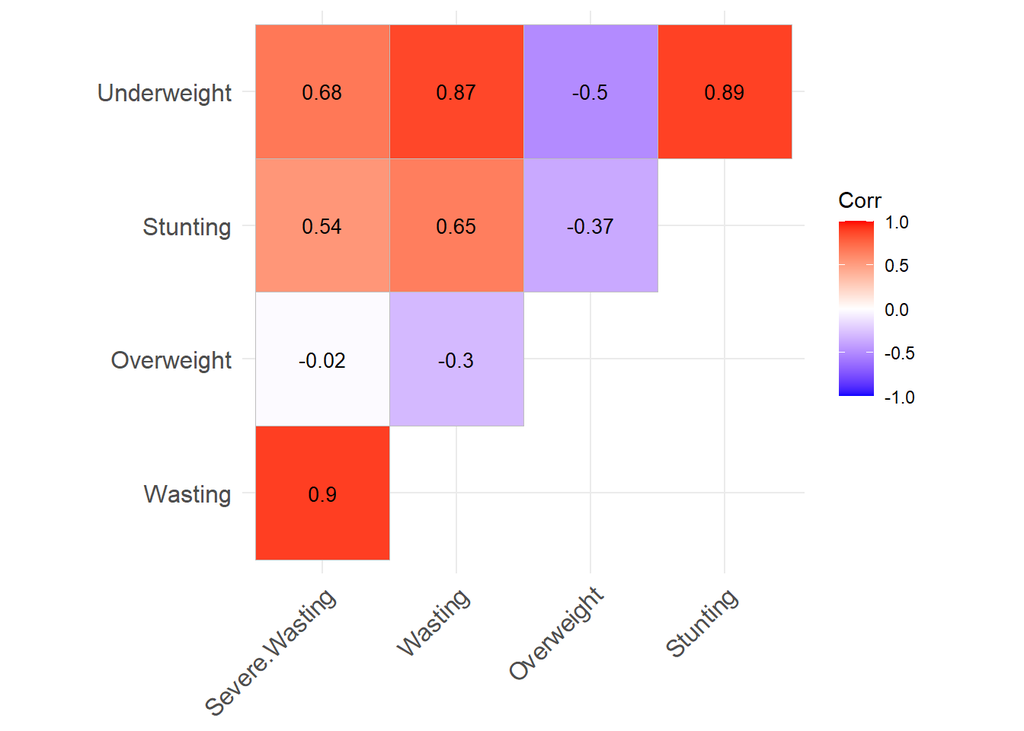

```r
#Grafico de correlação
ggcorrplot(cor(Nutri1),type="upper",lab=TRUE,lab_size=3.5)
```

Notável correlação positiva entre Severe.Wasting, Wasting, Stunting e Underweight. A alta correlação entre as duas primeiras já era esperada por Serere.Wasting medida está contida na Wasting.

O Overweigth mostrou comportamento diferente em relação as demais correções existentes. Indicando um possível afastamento das demais variáveis na redução de fatores.

### ACP

#### Procedimento de Análise de Componentes Principais

```r
# matriz de correlação(scale=T) utilizada, com dados padronizados(center=T)
acp<-prcomp(Nutri1, center=T, scale.=T) # outra função seria princomp(Nutri1,cor=T)

#autovaores - variâncias
summary(acp)
```

```
## Importance of components:
##                           PC1    PC2     PC3     PC4     PC5
## Standard deviation     1.8500 1.0207 0.66000 0.28855 0.12922
## Proportion of Variance 0.6845 0.2084 0.08712 0.01665 0.00334
## Cumulative Proportion  0.6845 0.8929 0.98001 0.99666 1.00000
```

```r
#autovetores - carga fatorial
summary(acp)$rotation
```

```
##                       PC1        PC2        PC3        PC4         PC5
## Severe.Wasting  0.4403885 -0.4956999  0.3359607 -0.5951612 -0.30537368
## Wasting         0.5060601 -0.2126939  0.3532750  0.4315907  0.62256783
## Overweight     -0.2456605 -0.8232197 -0.4316778  0.2737154 -0.02635352
## Stunting        0.4631854  0.1244338 -0.7390819 -0.3444426  0.32418008
## Underweight     0.5244725  0.1259703 -0.1724510  0.5157051 -0.64293777
```

```r
print(paste("Variância total:",sum(acp$sdev^2)))#soma dos quadrados dos desvios
```

```
## [1] "Variância total: 5"
```

```r
print(paste("Total de Variáveis Originaisl:",length(Nutri1)))#numero de variáveis
```

```
## [1] "Total de Variáveis Originaisl: 5"
```

O Resultado acima, mostra as variâncias de cada componente (Autovalor), assim como a proporção da variância explicada por cada componente.

Segundo (Mingoti 2013, 90), quando a matriz de correlação é utilizada na extração da componentes, a variância total `sum(acp$sdev^2)` = 5 é igual ao número de variáveis originais `length(Nutri1)` = 5. Assim, para escolha do número de componentes principais, o critério de Kaiser é indicado, o qual consiste em manter no sistema as componentes cujo autovalores são maior ou igual a 1 $(\hat{\lambda}\geq1)$.

Logo, seguindo o critério de Kaiser, as duas primeiras componentes são as únicas capazes de explicar a menos a quantidade de variância de uma variável original padronizada. Estes dois componentes são capazes de explicar 89,29% da variância total das variáveis originais.

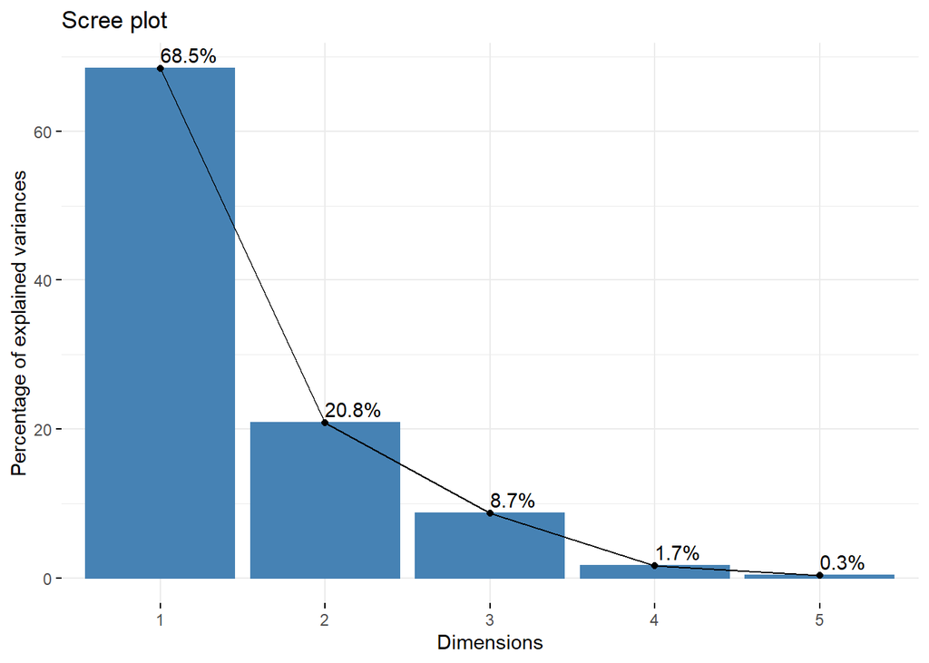

```r
fviz_eig(acp, addlabels = T)
```

Este gráfico mostra a contribuição de cada componente na explicação da variância dos dados. À medida que as componentes crescem, menor é a contribuição na explicação do comportamento do fato observado.

### Componentes

#### Avaliação dos Componentes

```r
#correlação entre os 2 primeiros componentes
kable((acp$sdev[1:2]*t(acp$rotation[,1:2])),digits = 3,
      caption = "Correlação entre os 2 principais componentes e as variáveis ")
```

Correlação entre os 2 principais componentes e as variáveis

|  | Severe.Wasting | Wasting | Overweight | Stunting | Underweight |
| --- | --- | --- | --- | --- | --- |
| PC1 | 0.815 | 0.936 | -0.454 | 0.857 | 0.970 |
| PC2 | -0.506 | -0.217 | -0.840 | 0.127 | 0.129 |

1º Componente com forte correlação com todas a variáveis, com exceção do Overweight 2º componente pode ser um contrate do Sobrepeso sob as demais variáveis

1º Componete pode ser entendido como um indicador de desnutrição. Dada a correlação acima, é possível afirmar que quanto maior o índice maior a incidência da desnutrição na população alvo.

#### Gráfico de classificação dos Países segundo o Indicador de Desnutrição (CP1)

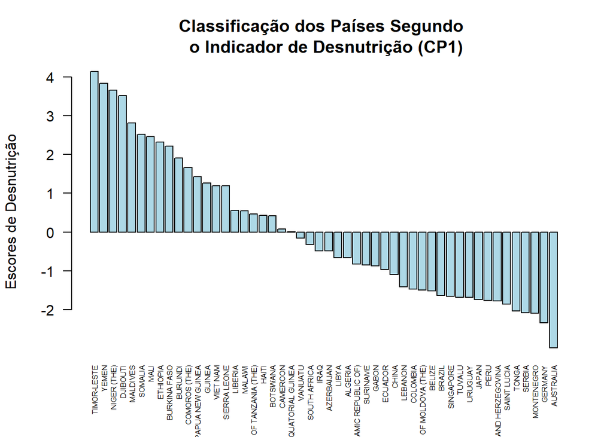

```r
escores <- acp$x[, 1]
ordem <- order(acp$x[, 1], decreasing = TRUE)
barplot(escores[ordem], ylab = "Escores de Desnutrição ", las = 2,
        cex.names = 0.5 , col="lightblue",
        main="Classificação dos Países Segundo \n o Indicador de Desnutrição (CP1)")
```

O gráfico acima apresenta como é possível utilizar os escores da Primeira Componente (CP1) - Índice de Desnutrição para classificar os países.

### Contrib 1

#### Contribuição Variáveis

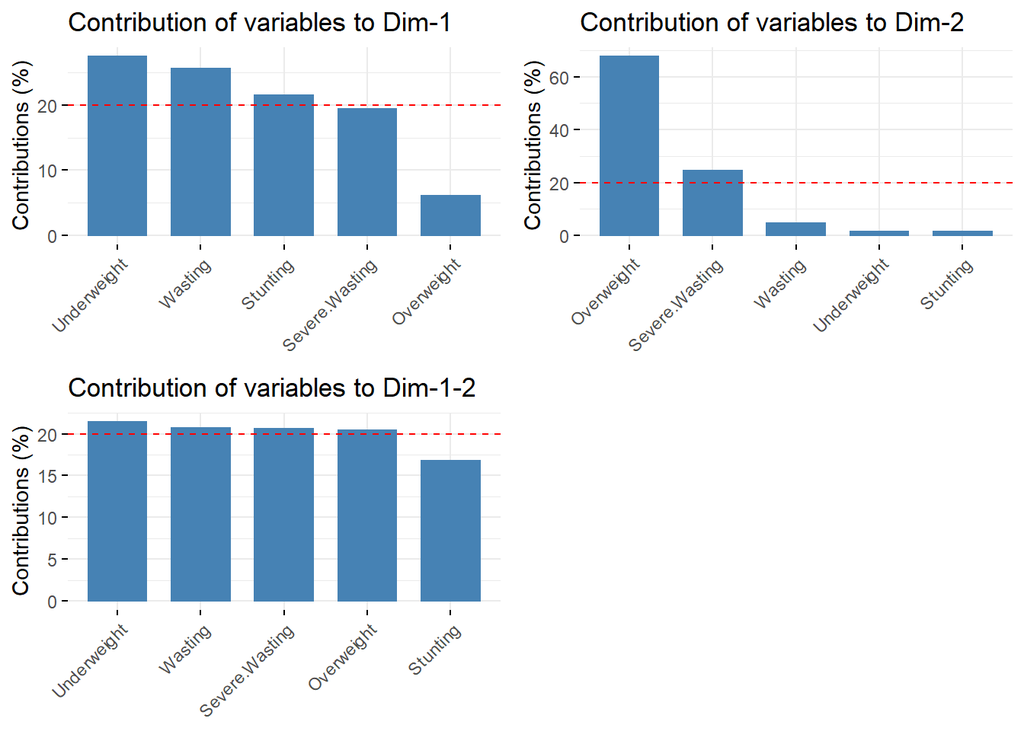

```r
#contribuição das variáveis ao modelo
PC1<-fviz_contrib(acp, choice = "var", axes = 1)
PC2<-fviz_contrib(acp, choice = "var", axes = 2)
PC<-fviz_contrib(acp, choice = "var", axes = 1:2)
grid.arrange(PC1, PC2, PC,nrow=2)
```

As representações acima mostram as contribuições das principais variáveis aos principais componentes do modelo descritor.

Conforme visto nos autovetores acima listados, foi possível constatar por meio de seus valores absolutos(cargas fatoriais) que a magnitude das variáveis Underweight, Wasting e Sturting era maior na CP1, enquanto Overweigght e Severe.Wasting contribuíam mais na CP2. E é exatamente isso que a representação acima está mostrando.

A linha de referência corresponde ao valor esperado se a contribuição for uniforme. Logo, uma contribuição acima da linha de referência pode ser considerada importante para contribuir com a dimensão.

### Contrib 2

#### Contribuição Elementos

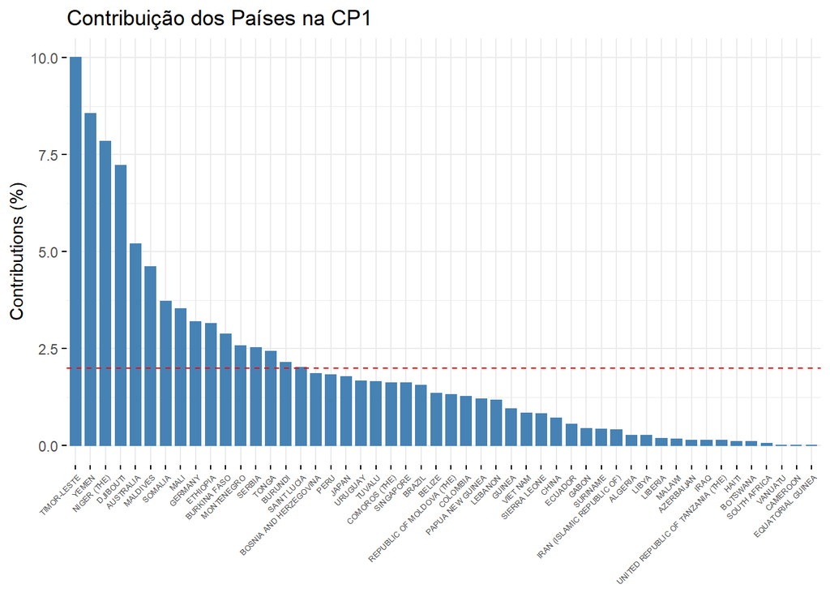

```r
#Contribução e cada linha do Dataframe
fviz_contrib(acp, choice = "ind", axes = 1) +
  ggtitle("Contribuição dos Países na CP1") +
  theme(axis.text.x = element_text(size = 5))
```

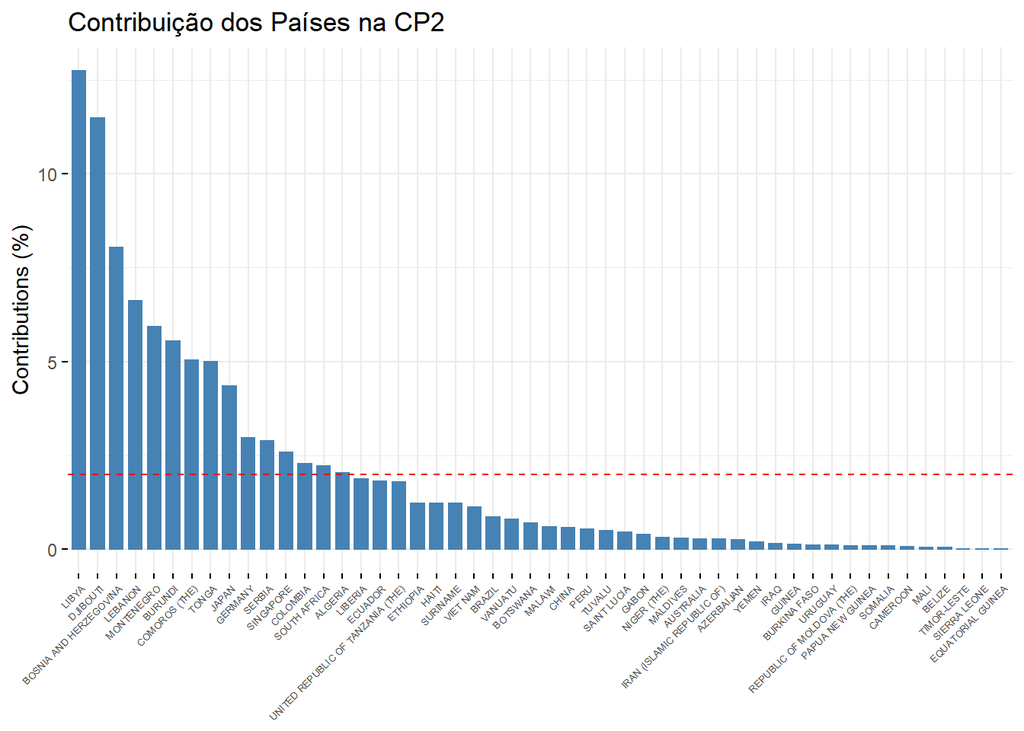

```r
fviz_contrib(acp, choice = "ind", axes = 2)+
  ggtitle("Contribuição dos Países na CP2") +
  theme(axis.text.x = element_text(size = 5))
```

### Biplot

Assim como nas variáveis, as representações acima mostram as contribuições dos países (cada elemento) em cada uma das duas principais componentes.

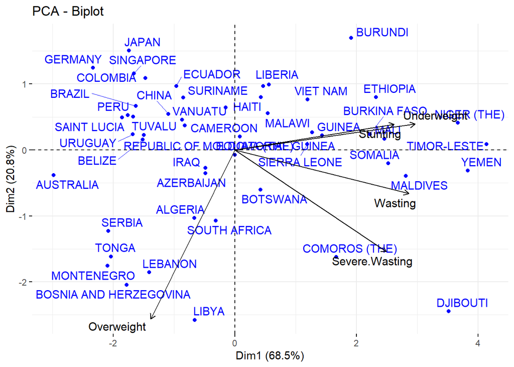

```r
fviz_pca_biplot(acp, repel = TRUE,
                col.var = "black", # cor das variáveis
                col.ind = "blue")
```

Grande dispersão dos Países, sem que seja possível identificar algum tipo de padrão a ser compreendido.

DJIBOUTI, COMOROS(THE) e BURUNDI estão mais afastados parecem ser outliers.

Os autovetores (cargas fatoriais) Underweight, Stunting, Wasting e Severe. Wasting tem grandes cargas positivas no componente 1. Já Overweight contribui com carga fatorial negativa para o componente 2.

## Questão 02

2. Faça um biplot em que os países são identificados (cor e/ou tipo de ponto) de acordo como a renda. Você consegue observar alguma relação entre os países mais parecidos segundo a análise de componentes principais e sua categoria de renda?

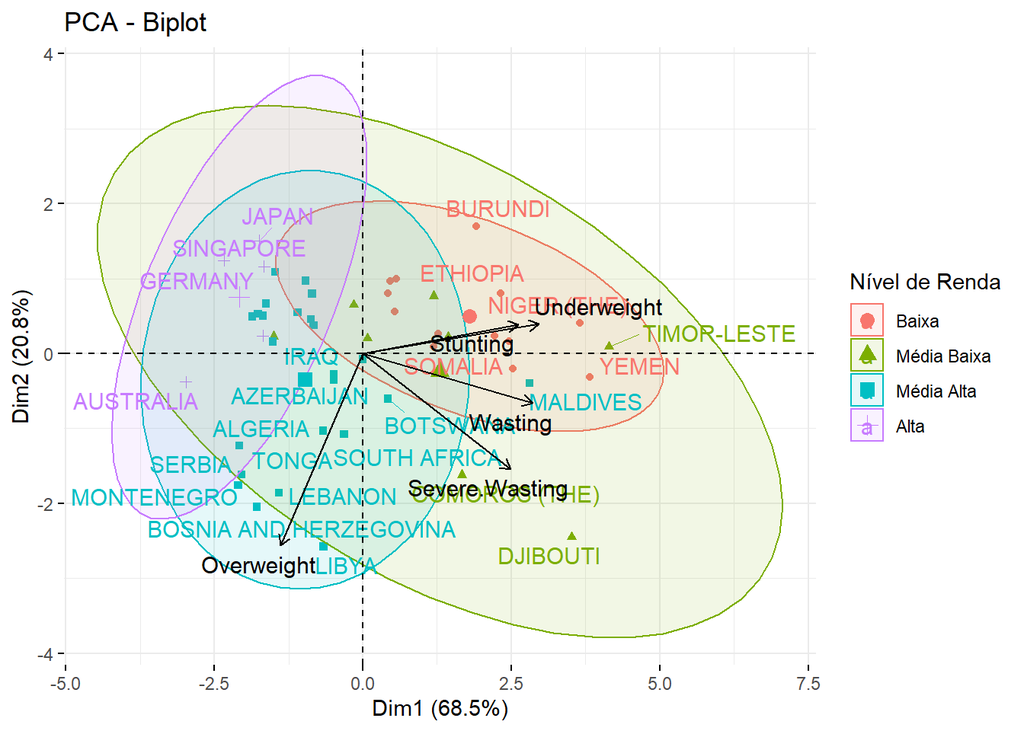

```r
Nutri<-cbind(Nutri,Income=factor(Nutri[,3], levels = c(0:3),
                                 labels = c("Baixa","Média Baixa","Média Alta","Alta")))
fviz_pca_biplot(acp, repel = TRUE,
                col.var = "black",       # cor das variáveis
                col.ind = Nutri$Income, # cor dos paises
                addEllipses = TRUE,
                legend.title = "Nível de Renda")
```

Considerando a Componente 01 - Indicador de Desnutrição, é possível notar o quanto os extremos dos níveis de renda estão em lados opostos.

Países com nível de renda **alto** como Japão, Alemanha e Austrália aparecem totalmente no lado de contribuição negativa para a desnutrição, assim como a maioria dos países com nível de renda **média alta**.

Logo, não seria incoerente afirmar que do ponto de vista da componente 1, existem dois grandes grupos distintos de países conforme o nível de renda. Sendo plausível dizer que uma relação inversa entre renda e desnutrição esteja presente no espaço amostral em questão.

## Questão 03

3. Considerando as mesmas variáveis da análise anterior, faça um dendrograma para classificar os países em grupos (clusters). Experimente fazê-lo colorido selecionando diferentes números de grupos. Os resultados são condizentes com os da análise de componentes principais?

```r
#Padronizando as colunas do datraframe
NutriS<-apply(Nutri1,MARGIN=2,FUN="scale")
row.names(NutriS)<-row.names(Nutri1)

dist.NutriS<-dist(NutriS,method="minkowski", p=2)
# Distância menos afetada pela presença de outliers
# p=2 distancia como se fosse dentro de um circulo
# https://stackoverflow.com/questions/47526577/plot-the-minkowski-distance-with-different-p

clust.NutriS<-hclust(dist.NutriS,method="ward.D2")
#Método de variação mínima de Ward com dissimilaridades são elevadas ao quadrado antes do agrupamento

dend<-as.dendrogram(clust.NutriS)

#par(mar=c(6,4,1,1))
cores <- c("#ff8000","#1a1aff","#669900","#e6e600","#cc00cc")
```

```r
for (i in 2:5){
  cat("###", "Dendrama",i-1,'\n')
  plot(color_branches(dend,k=i,col=cores[1:5]),
             main=paste0("K=",i,"; Dist:Minkowski; Hclust:ward.D2"))
  cat( '\n\n')
}
```

### Dendrama 1

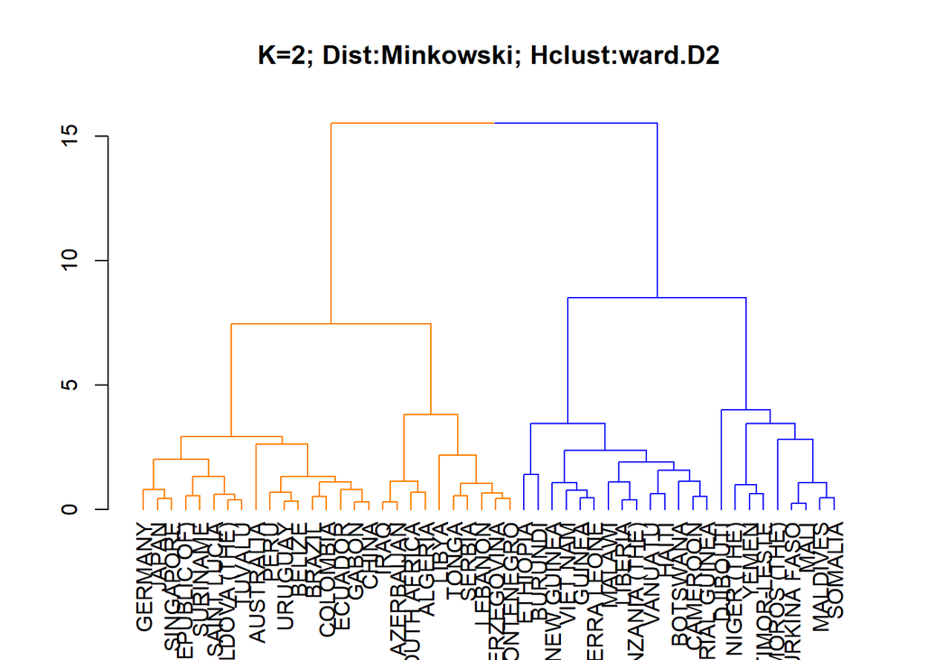

### Dendrama 2

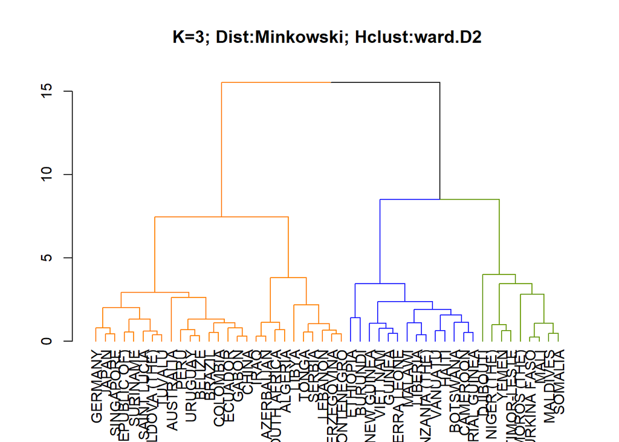

### Dendrama 3

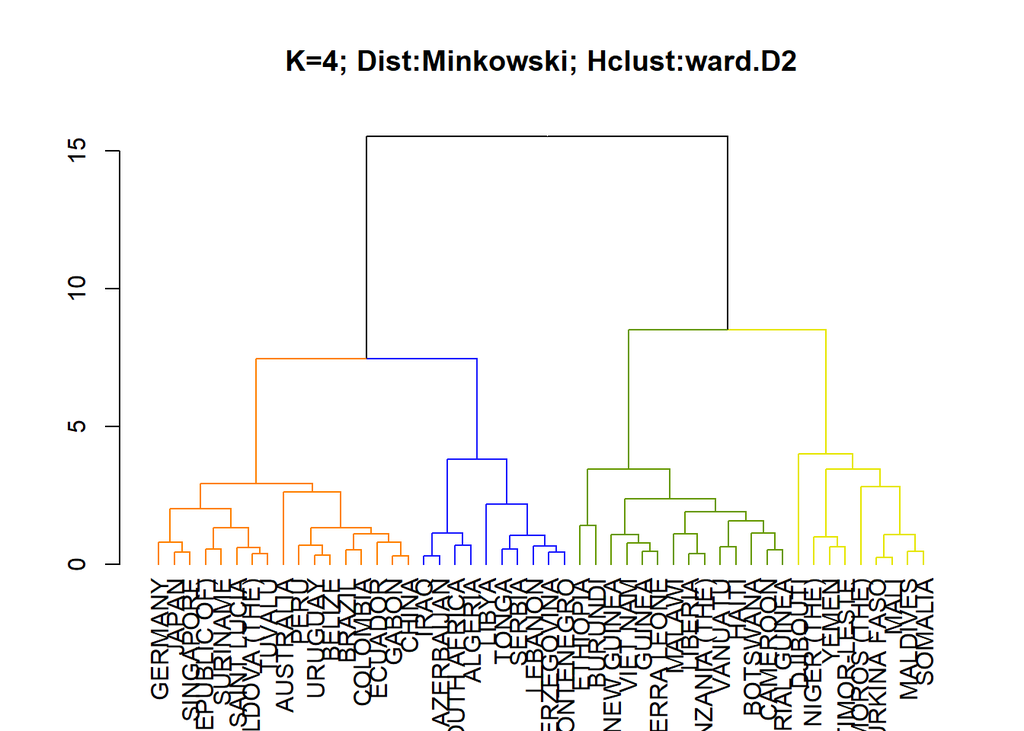

### Dendrama 4

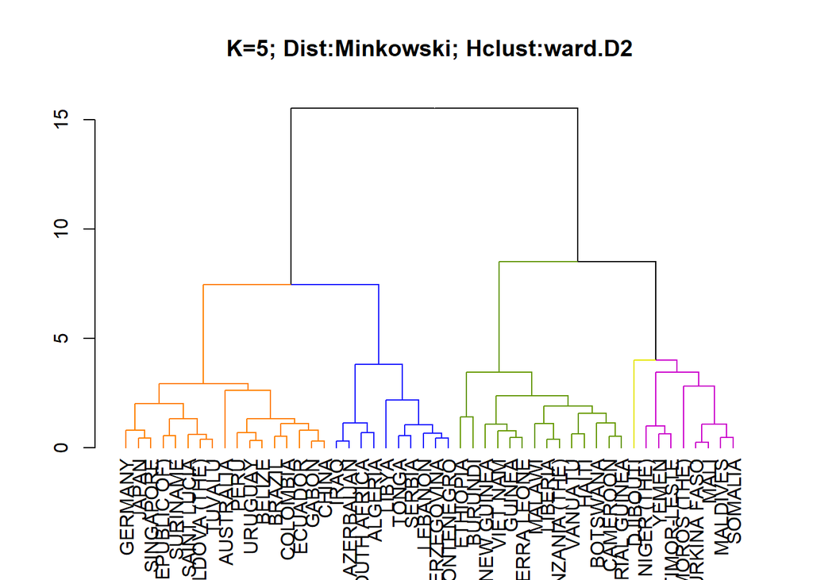

Os clusters formados com K=4 apresentam semelhança com os grupos de países em cada quadrante no Biplot.

## Questão 04

4. Ainda considerando as mesmas variáveis das análises anteriores, utilize o algoritmo k-means para classificar os países em grupos. Experimente diferentes números de grupos e faca gráficos em que as observações são plotadas nas coordenadas das componentes principais e os grupos estejam identificados. Os resultados são condizentes com os das análises anteriores?

```r
K<-list(k2=NULL,k3=NULL,k4=NULL,k5=NULL)
#P<-list(p2=NULL,p3=NULL,p4=NULL,p5=NULL)

for (i in 1:4){
  K[i]<-list(kmeans(NutriS,i+1))
  #P[i]<-list(fviz_cluster(K[[i]],data=NutriS) + labs(title=names(K[i])))
}
```

### k2

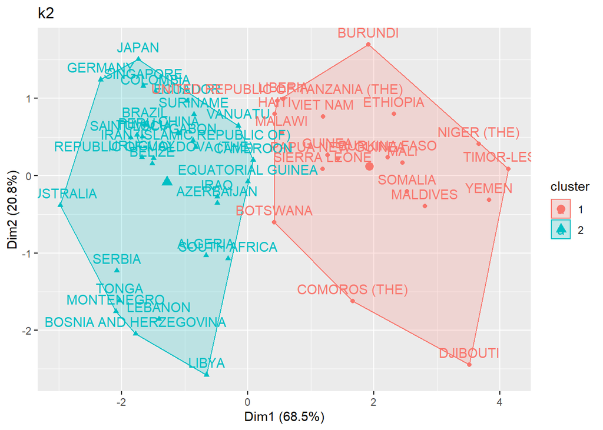

### k3

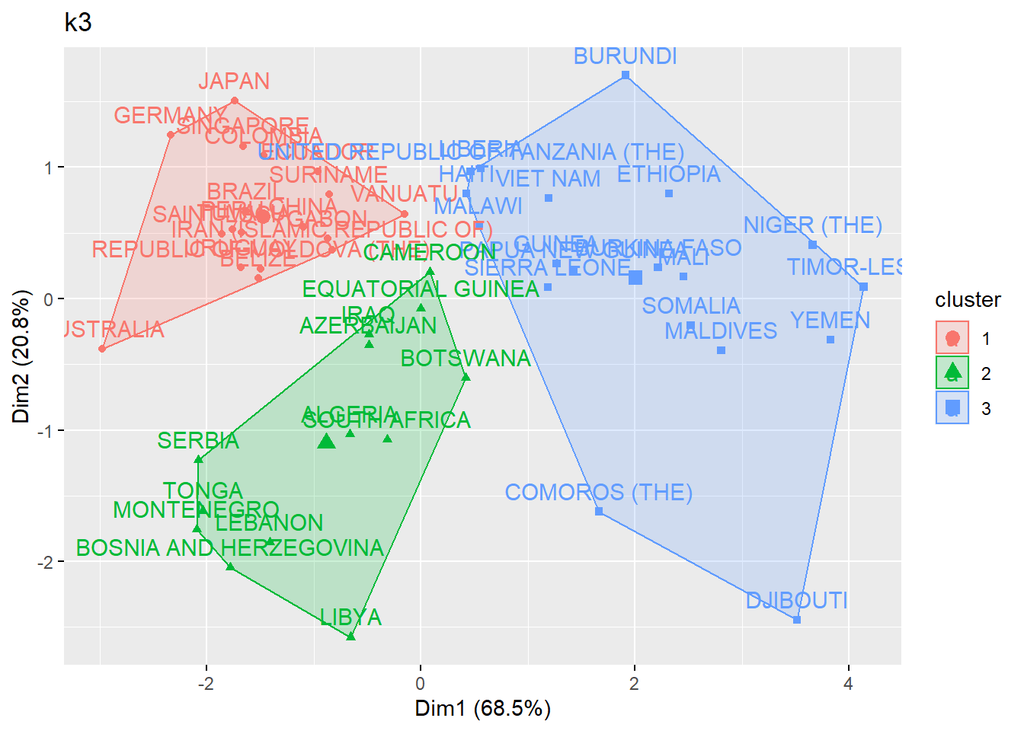

### k4

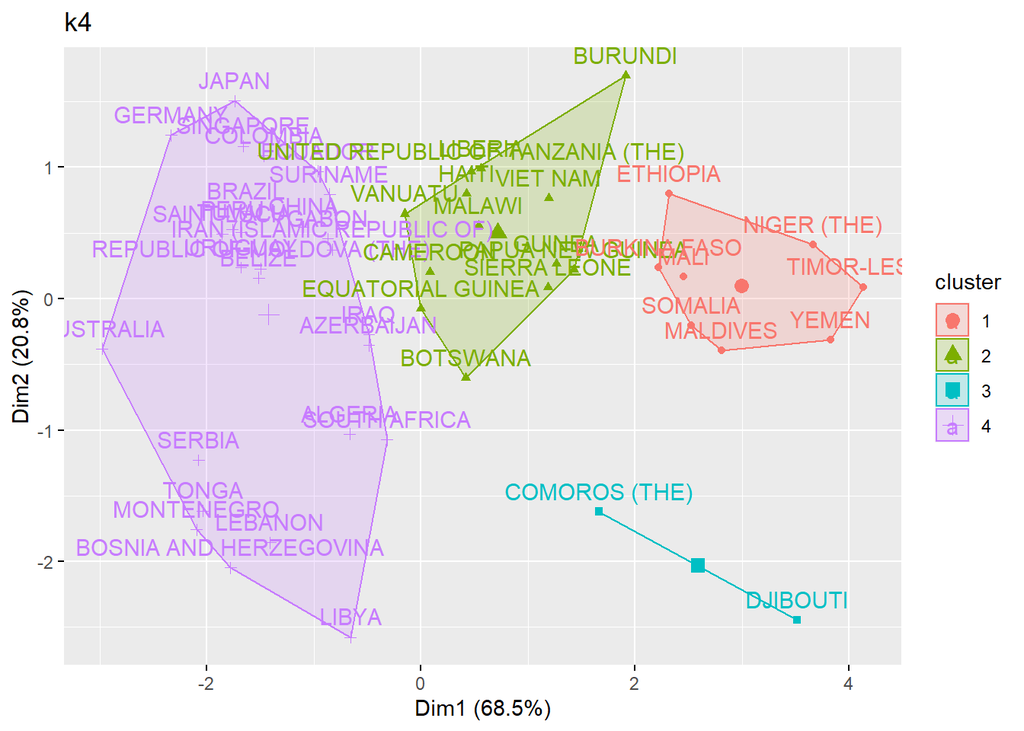

### k5

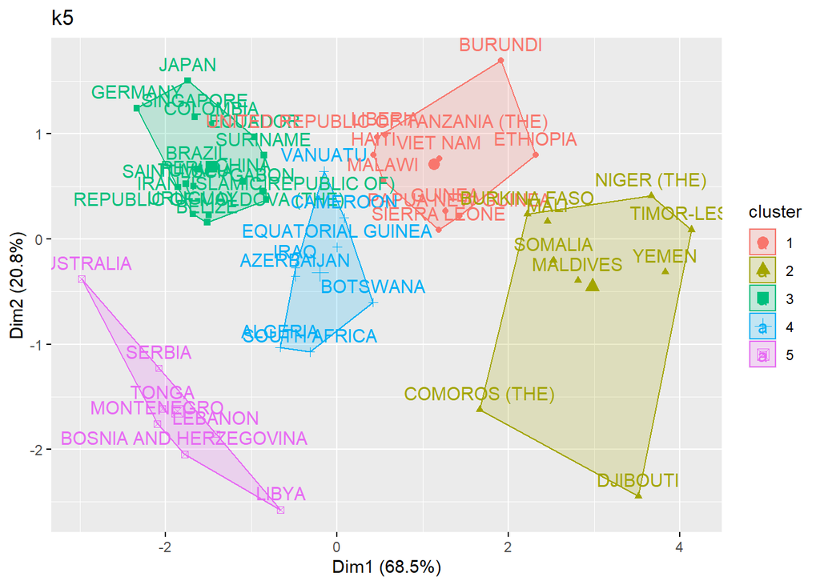

# Referências Bibliográficas

Mingoti, Sueli Aparecida. 2013. *Análise de Dados Através de Métodos de Estatística Multivariada: Uma abordagem aplicada*. Belo Horizonte: Ed. UFMG.